# EDA_TinaYoung

Tina Young

2025-02-16

# EDA Introduction

This document will cover details regarding the data for Kaggle Home Credit Default Risk project. Details will include descriptions of the available data as well as some concerns and initial findings of the data.

## Project questions

- How will my imputation of data affect predictions?
- Any outliers in the data?
- Are there columns that have multicollinearity?
- What types of visualizations will best represent initial observations of the data?
- Will the size of the merged file be an increase in complexity in the project?
- How will having big data files affect processing times? Are there ways to mitigated this issue?

## The Data

```r
app_train <- read.csv("C:\\Users\\young\\OneDrive\\Documents\\Masters\\Spring 2025\\IS 6812 - Capstone 2\\kaggle\\kaggle data\\application_train.csv")

cbu <- read.csv("C:\\Users\\young\\OneDrive\\Documents\\Masters\\Spring 2025\\IS 6812 - Capstone 2\\kaggle\\kaggle data\\bureau.csv")

prev_app <- read.csv("C:\\Users\\young\\OneDrive\\Documents\\Masters\\Spring 2025\\IS 6812 - Capstone 2\\kaggle\\kaggle data\\previous_application.csv")
```

### Application_train file

#### Summary views and confirmation of columns with missing or NA data

```r
#standard summary of app_train file
summary(app_train)
```

```
##    SK_ID_CURR         TARGET        NAME_CONTRACT_TYPE CODE_GENDER
##  Min.   :100002   Min.   :0.00000   Length:307511      Length:307511
##  1st Qu.:189146   1st Qu.:0.00000   Class :character   Class :character
##  Median :278202   Median :0.00000   Mode  :character   Mode  :character
##  Mean   :278181   Mean   :0.08073
##  3rd Qu.:367143   3rd Qu.:0.00000
##  Max.   :456255   Max.   :1.00000
##
##  FLAG_OWN_CAR       FLAG_OWN_REALTY     CNT_CHILDREN     AMT_INCOME_TOTAL
##  Length:307511      Length:307511      Min.   : 0.0000   Min.   :    25650
##  Class :character   Class :character   1st Qu.: 0.0000   1st Qu.:   112500
##  Mode  :character   Mode  :character   Median : 0.0000   Median :   147150
##                                        Mean   : 0.4171   Mean   :   168798
##                                        3rd Qu.: 1.0000   3rd Qu.:   202500
##                                        Max.   :19.0000   Max.   :117000000
##
##    AMT_CREDIT       AMT_ANNUITY     AMT_GOODS_PRICE   NAME_TYPE_SUITE
##  Min.   :  45000   Min.   :  1616   Min.   :  40500   Length:307511
##  1st Qu.: 270000   1st Qu.: 16524   1st Qu.: 238500   Class :character
##  Median : 513531   Median : 24903   Median : 450000   Mode  :character
##  Mean   : 599026   Mean   : 27109   Mean   : 538396
##  3rd Qu.: 808650   3rd Qu.: 34596   3rd Qu.: 679500
##  Max.   :4050000   Max.   :258026   Max.   :4050000
##                    NA's   :12       NA's   :278
##  NAME_INCOME_TYPE   NAME_EDUCATION_TYPE NAME_FAMILY_STATUS NAME_HOUSING_TYPE
##  Length:307511      Length:307511       Length:307511      Length:307511
##  Class :character   Class :character    Class :character   Class :character
##  Mode  :character   Mode  :character    Mode  :character   Mode  :character
##
##
##
##
##  REGION_POPULATION_RELATIVE   DAYS_BIRTH     DAYS_EMPLOYED    DAYS_REGISTRATION
##  Min.   :0.00029            Min.   :-25229   Min.   :-17912   Min.   :-24672
##  1st Qu.:0.01001            1st Qu.:-19682   1st Qu.: -2760   1st Qu.: -7480
##  Median :0.01885            Median :-15750   Median : -1213   Median : -4504
##  Mean   :0.02087            Mean   :-16037   Mean   : 63815   Mean   : -4986
##  3rd Qu.:0.02866            3rd Qu.:-12413   3rd Qu.:  -289   3rd Qu.: -2010
##  Max.   :0.07251            Max.   : -7489   Max.   :365243   Max.   :     0
##
```

[output cut: 225 more lines]

```
##  Min.   :0.00               Min.   : 0.00             Min.   :  0.00
##  1st Qu.:0.00               1st Qu.: 0.00             1st Qu.:  0.00
##  Median :0.00               Median : 0.00             Median :  0.00
##  Mean   :0.03               Mean   : 0.27             Mean   :  0.27
##  3rd Qu.:0.00               3rd Qu.: 0.00             3rd Qu.:  0.00
##  Max.   :8.00               Max.   :27.00             Max.   :261.00
##  NA's   :41519              NA's   :41519             NA's   :41519
##  AMT_REQ_CREDIT_BUREAU_YEAR
##  Min.   : 0.0
##  1st Qu.: 0.0
##  Median : 1.0
##  Mean   : 1.9
##  3rd Qu.: 3.0
##  Max.   :25.0
##  NA's   :41519
```

A list of non-character columns with missing data

```r
na <- colSums(is.na(app_train))
na[na > 0]
```

```
##                  AMT_ANNUITY              AMT_GOODS_PRICE
##                           12                          278
##                  OWN_CAR_AGE              CNT_FAM_MEMBERS
##                       202929                            2
##                 EXT_SOURCE_1                 EXT_SOURCE_2
##                       173378                          660
##                 EXT_SOURCE_3               APARTMENTS_AVG
##                        60965                       156061
##             BASEMENTAREA_AVG  YEARS_BEGINEXPLUATATION_AVG
##                       179943                       150007
##              YEARS_BUILD_AVG               COMMONAREA_AVG
##                       204488                       214865
##                ELEVATORS_AVG                ENTRANCES_AVG
##                       163891                       154828
##                FLOORSMAX_AVG                FLOORSMIN_AVG
##                       153020                       208642
##                 LANDAREA_AVG         LIVINGAPARTMENTS_AVG
##                       182590                       210199
##               LIVINGAREA_AVG      NONLIVINGAPARTMENTS_AVG
##                       154350                       213514
##            NONLIVINGAREA_AVG              APARTMENTS_MODE
##                       169682                       156061
##            BASEMENTAREA_MODE YEARS_BEGINEXPLUATATION_MODE
##                       179943                       150007
##             YEARS_BUILD_MODE              COMMONAREA_MODE
##                       204488                       214865
##               ELEVATORS_MODE               ENTRANCES_MODE
##                       163891                       154828
##               FLOORSMAX_MODE               FLOORSMIN_MODE
##                       153020                       208642
##                LANDAREA_MODE        LIVINGAPARTMENTS_MODE
##                       182590                       210199
##              LIVINGAREA_MODE     NONLIVINGAPARTMENTS_MODE
##                       154350                       213514
##           NONLIVINGAREA_MODE              APARTMENTS_MEDI
##                       169682                       156061
##            BASEMENTAREA_MEDI YEARS_BEGINEXPLUATATION_MEDI
##                       179943                       150007
##             YEARS_BUILD_MEDI              COMMONAREA_MEDI
##                       204488                       214865
##               ELEVATORS_MEDI               ENTRANCES_MEDI
##                       163891                       154828
##               FLOORSMAX_MEDI               FLOORSMIN_MEDI
##                       153020                       208642
##                LANDAREA_MEDI        LIVINGAPARTMENTS_MEDI
##                       182590                       210199
##              LIVINGAREA_MEDI     NONLIVINGAPARTMENTS_MEDI
##                       154350                       213514
##           NONLIVINGAREA_MEDI               TOTALAREA_MODE
##                       169682                       148431
##     OBS_30_CNT_SOCIAL_CIRCLE     DEF_30_CNT_SOCIAL_CIRCLE
##                         1021                         1021
##     OBS_60_CNT_SOCIAL_CIRCLE     DEF_60_CNT_SOCIAL_CIRCLE
##                         1021                         1021
##       DAYS_LAST_PHONE_CHANGE   AMT_REQ_CREDIT_BUREAU_HOUR
##                            1                        41519
##    AMT_REQ_CREDIT_BUREAU_DAY   AMT_REQ_CREDIT_BUREAU_WEEK
##                        41519                        41519
##    AMT_REQ_CREDIT_BUREAU_MON    AMT_REQ_CREDIT_BUREAU_QRT
##                        41519                        41519
##   AMT_REQ_CREDIT_BUREAU_YEAR
##                        41519
```

Reviewed the character data columns to see if they have NA or blank data.

```r
app_train1 <- app_train |>
  select(where(is.character)) |>
  map_df(~ sum(is.na(.) | . == "", na.rm = TRUE)) |> #searching for blank or NA values
  pivot_longer(cols = everything(), names_to = "column", values_to = "blank_count") |>
  filter(blank_count > 0)

app_train1
```

```
## # A tibble: 6 × 2
##   column              blank_count
##   <chr>                     <int>
## 1 NAME_TYPE_SUITE            1292
## 2 OCCUPATION_TYPE           96391
## 3 FONDKAPREMONT_MODE       210295
## 4 HOUSETYPE_MODE           154297
## 5 WALLSMATERIAL_MODE       156341
## 6 EMERGENCYSTATE_MODE      145755
```

These 6 columns have blank or NA in the values as shown out of 307,511 rows. After visually reviewing the columns it is determined that the cells were blank. Due to the size of missing/blank cells with the highest percentage of blank at 68%.

#### Application_Train Data observations

Additionally, columns FLAG_OWN_CAR and OWN_CAR_AGE having a dependency that if Y would have a numerical value and if N the cell was blank. With this need to be aware and decide how to impute this to be clear on the meaning. The oldest car age is listed as 91.

#### Application_Train file Cleaning

Updating the character columns so that the missing values will proportionally be updated to match what values are available.

```r
#Copy of original data
clean_app_train <- app_train
#Using the copy for cleaning and saving, staring here will be cleaning for the character data with blank fields
redistribute_blanks <- function(clean_app_train, column_name) {
  #remove blank values to calculate proportions
  non_blank_app_train <- clean_app_train %>% filter(!!sym(column_name) != "")

  #Calculate proportions of each non-blank category
  proportions <- non_blank_app_train %>%
    count(!!sym(column_name)) %>%
    mutate(Prop = n/sum(n)) #proportion of each category

  #Number of blank values to redistribute
  blank_count <- nrow(clean_app_train %>% filter(!!sym(column_name) == ""))

  #Assign blank value proportionally
  set.seed(123) #repoducability

  clean_app_train[[column_name]][clean_app_train[[column_name]] == ""] <- sample(
    proportions[[column_name]],
    blank_count,
    replace = TRUE,
    prob = proportions$Prop
  )

  return(clean_app_train)
}
#applying the function to select columns, applying to the character columns that had missing or blank data
columns_to_process <- c("NAME_TYPE_SUITE", "OCCUPATION_TYPE", "FONDKAPREMONT_MODE", "HOUSETYPE_MODE", "WALLSMATERIAL_MODE", "EMERGENCYSTATE_MODE")

for (column in columns_to_process) {
  print(paste("Processing column:", column))  # Debugging step
  clean_app_train <- redistribute_blanks(clean_app_train, column)
}
```

```
## [1] "Processing column: NAME_TYPE_SUITE"
## [1] "Processing column: OCCUPATION_TYPE"
## [1] "Processing column: FONDKAPREMONT_MODE"
## [1] "Processing column: HOUSETYPE_MODE"
## [1] "Processing column: WALLSMATERIAL_MODE"
## [1] "Processing column: EMERGENCYSTATE_MODE"
```

For numbered data, first updated the OWN_CAR_AGE column by itself to ensure that the na values, that match up to the N flag continue to make sense.

```r
clean_app_train <- clean_app_train |>
  mutate(OWN_CAR_AGE = replace_na(data = OWN_CAR_AGE, replace = 999)) # Selecting to update to 999 as it is an out of place value that doesn't match existing values
```

The remainder numbered column types. Also imputing the missing values to be proportionally updated to what is already existing.

```r
# Handling values for the numeric and integer data types where they have NA values (using clean_app_train as it has already been partially cleaned)
# Function to apply proportional filling to multiple columns
proportional_fill_multiple_cols <- function(clean_app_train, column_names) {

  # Loop through each column name
  for (column_name in column_names) {
    print(paste("Processing column:", column_name))  # Debugging output

    # Count number of missing (NA) values
    num_na <- sum(is.na(clean_app_train[[column_name]]))

    # Existing values (non-missing)
    num_values <- clean_app_train[[column_name]][!is.na(clean_app_train[[column_name]])]

    if (length(num_values) > 0 && num_na > 0) {
      # Get the probability distribution of existing values
      value_counts <- table(num_values)  # Frequency of unique values
      proportions <- value_counts / sum(value_counts)  # Convert to proportions

      # Sampling missing values based on proportions
      set.seed(123)  # For reproducibility
      sampled_values <- sample(
        as.numeric(names(proportions)),  # Convert names back to numeric
        size = num_na,
        replace = TRUE,
        prob = proportions
      )

      # Replace NA values with sampled values
      clean_app_train[[column_name]][is.na(clean_app_train[[column_name]])] <- sampled_values

      print(paste("Updated column:", column_name, "- Filled NAs:", num_na))
    } else {
      print(paste("No valid values to sample from for column:", column_name))
    }
  }

  return(clean_app_train)
}
#applying function
num_columns_to_process <- names(which(colSums(is.na(clean_app_train)) > 0))

for (column in num_columns_to_process) {
  print(paste("Processing column:", column)) #Debuggin
  clean_app_train <- proportional_fill_multiple_cols(clean_app_train, column)
}
```

```
## [1] "Processing column: AMT_ANNUITY"
## [1] "Processing column: AMT_ANNUITY"
## [1] "Updated column: AMT_ANNUITY - Filled NAs: 12"
## [1] "Processing column: AMT_GOODS_PRICE"
## [1] "Processing column: AMT_GOODS_PRICE"
## [1] "Updated column: AMT_GOODS_PRICE - Filled NAs: 278"
## [1] "Processing column: CNT_FAM_MEMBERS"
## [1] "Processing column: CNT_FAM_MEMBERS"
## [1] "Updated column: CNT_FAM_MEMBERS - Filled NAs: 2"
## [1] "Processing column: EXT_SOURCE_1"
## [1] "Processing column: EXT_SOURCE_1"
## [1] "Updated column: EXT_SOURCE_1 - Filled NAs: 173378"
## [1] "Processing column: EXT_SOURCE_2"
## [1] "Processing column: EXT_SOURCE_2"
## [1] "Updated column: EXT_SOURCE_2 - Filled NAs: 660"
```

[output cut: 165 more lines]

```r
count_missing <- function(x) sum(is.na(x))

clean_app_train |>
  summarize_all(count_missing) |>
  pivot_longer(cols = everything(), names_to = "column", values_to = "missing_count") |>
  filter(missing_count > 0)
```

```
## # A tibble: 0 × 2
## # ℹ 2 variables: column <chr>, missing_count <int>
```

No more data is missing or NA.

#### Application Train visualizations

Visual difference for counts of the TARGET variable

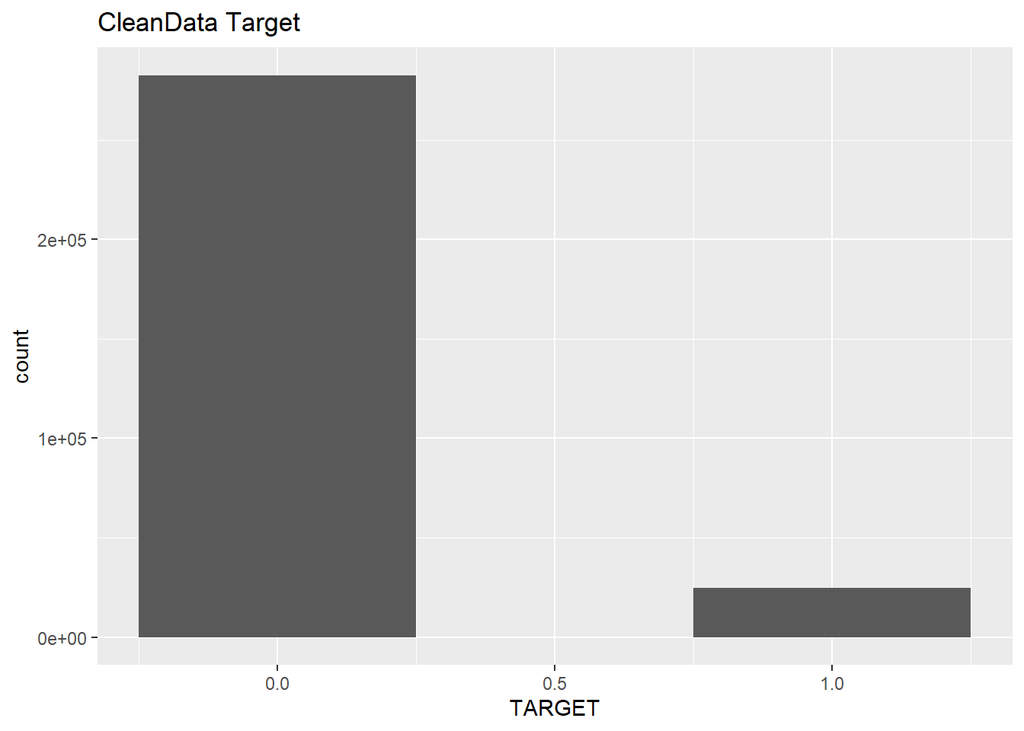

```r
ggplot(clean_app_train, aes(x = TARGET)) +
  geom_histogram(binwidth = 0.5)+
  labs(title="CleanData Target")
```

The count is showing that majority of clients are being marked as 0, for no late payments.

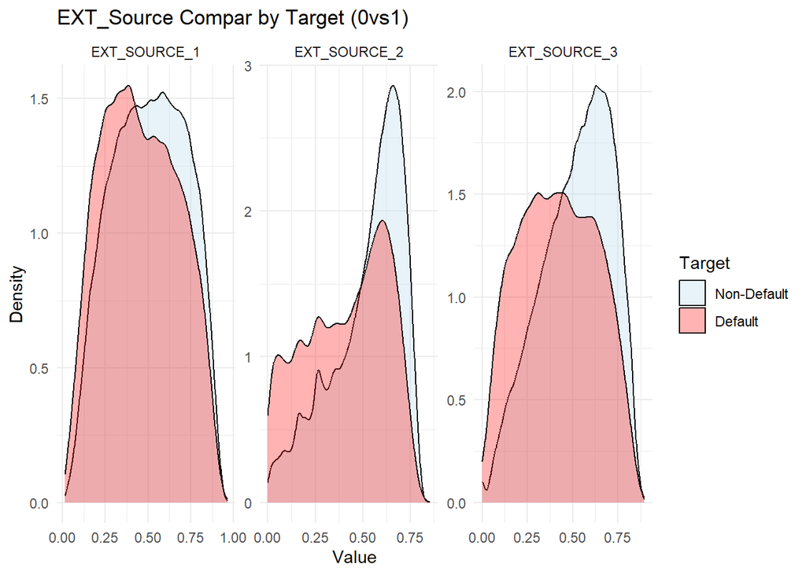

```r
clean_app_compare <- clean_app_train |>
  select(TARGET, EXT_SOURCE_1, EXT_SOURCE_2, EXT_SOURCE_3) |>
  pivot_longer(cols = starts_with("EXT_SOURCE"), names_to = "Source", values_to = "Value")

clean_app_compare |>
  ggplot(aes(x=Value, fill=factor(TARGET))) +
  geom_density(alpha = 0.3) +
  facet_wrap(~ Source, scales = "free") +
  scale_fill_manual(values = c("0" = "lightblue", "1" = "red"),
                    labels = c("0" = "Non-Default", "1" = "Default")) +
  labs(title = "EXT_Source Compar by Target (0vs1)",
       x = "Value",
       y = "Density",
       fill = "Target") +
  theme_minimal()
```

### Bureau data file

#### Bureau Summary views and confirmation of columns with missing or NA data

```r
#standard summary of app_train file
summary(cbu)
```

```
##    SK_ID_CURR      SK_ID_BUREAU     CREDIT_ACTIVE      CREDIT_CURRENCY
##  Min.   :100001   Min.   :5000000   Length:1716428     Length:1716428
##  1st Qu.:188867   1st Qu.:5463954   Class :character   Class :character
##  Median :278055   Median :5926304   Mode  :character   Mode  :character
##  Mean   :278215   Mean   :5924434
##  3rd Qu.:367426   3rd Qu.:6385681
##  Max.   :456255   Max.   :6843457
##
##   DAYS_CREDIT    CREDIT_DAY_OVERDUE  DAYS_CREDIT_ENDDATE DAYS_ENDDATE_FACT
##  Min.   :-2922   Min.   :   0.0000   Min.   :-42060.0    Min.   :-42023
##  1st Qu.:-1666   1st Qu.:   0.0000   1st Qu.: -1138.0    1st Qu.: -1489
##  Median : -987   Median :   0.0000   Median :  -330.0    Median :  -897
##  Mean   :-1142   Mean   :   0.8182   Mean   :   510.5    Mean   : -1017
##  3rd Qu.: -474   3rd Qu.:   0.0000   3rd Qu.:   474.0    3rd Qu.:  -425
##  Max.   :    0   Max.   :2792.0000   Max.   : 31199.0    Max.   :     0
##                                      NA's   :105553      NA's   :633653
##  AMT_CREDIT_MAX_OVERDUE CNT_CREDIT_PROLONG AMT_CREDIT_SUM
##  Min.   :        0      Min.   :0.00000    Min.   :        0
##  1st Qu.:        0      1st Qu.:0.00000    1st Qu.:    51300
##  Median :        0      Median :0.00000    Median :   125518
##  Mean   :     3825      Mean   :0.00641    Mean   :   354995
##  3rd Qu.:        0      3rd Qu.:0.00000    3rd Qu.:   315000
##  Max.   :115987185      Max.   :9.00000    Max.   :585000000
##  NA's   :1124488                           NA's   :13
##  AMT_CREDIT_SUM_DEBT AMT_CREDIT_SUM_LIMIT AMT_CREDIT_SUM_OVERDUE
##  Min.   : -4705600   Min.   :-586406      Min.   :      0
##  1st Qu.:        0   1st Qu.:      0      1st Qu.:      0
##  Median :        0   Median :      0      Median :      0
##  Mean   :   137085   Mean   :   6230      Mean   :     38
##  3rd Qu.:    40154   3rd Qu.:      0      3rd Qu.:      0
##  Max.   :170100000   Max.   :4705600      Max.   :3756681
##  NA's   :257669      NA's   :591780
##  CREDIT_TYPE        DAYS_CREDIT_UPDATE  AMT_ANNUITY
##  Length:1716428     Min.   :-41947.0   Min.   :        0
##  Class :character   1st Qu.:  -908.0   1st Qu.:        0
##  Mode  :character   Median :  -395.0   Median :        0
##                     Mean   :  -593.8   Mean   :    15713
##                     3rd Qu.:   -33.0   3rd Qu.:    13500
##                     Max.   :   372.0   Max.   :118453424
##                                        NA's   :1226791
```

```r
str(cbu)
```

```
## 'data.frame':    1716428 obs. of  17 variables:
##  $ SK_ID_CURR            : int  215354 215354 215354 215354 215354 215354 215354 162297 162297 162297 ...
##  $ SK_ID_BUREAU          : int  5714462 5714463 5714464 5714465 5714466 5714467 5714468 5714469 5714470 5714471 ...
##  $ CREDIT_ACTIVE         : chr  "Closed" "Active" "Active" "Active" ...
##  $ CREDIT_CURRENCY       : chr  "currency 1" "currency 1" "currency 1" "currency 1" ...
##  $ DAYS_CREDIT           : int  -497 -208 -203 -203 -629 -273 -43 -1896 -1146 -1146 ...
##  $ CREDIT_DAY_OVERDUE    : int  0 0 0 0 0 0 0 0 0 0 ...
##  $ DAYS_CREDIT_ENDDATE   : num  -153 1075 528 NA 1197 ...
##  $ DAYS_ENDDATE_FACT     : num  -153 NA NA NA NA NA NA -1710 -840 NA ...
##  $ AMT_CREDIT_MAX_OVERDUE: num  NA NA NA NA 77675 ...
##  $ CNT_CREDIT_PROLONG    : int  0 0 0 0 0 0 0 0 0 0 ...
##  $ AMT_CREDIT_SUM        : num  91323 225000 464324 90000 2700000 ...
##  $ AMT_CREDIT_SUM_DEBT   : num  0 171342 NA NA NA ...
##  $ AMT_CREDIT_SUM_LIMIT  : num  NA NA NA NA NA ...
##  $ AMT_CREDIT_SUM_OVERDUE: num  0 0 0 0 0 0 0 0 0 0 ...
##  $ CREDIT_TYPE           : chr  "Consumer credit" "Credit card" "Consumer credit" "Credit card" ...
##  $ DAYS_CREDIT_UPDATE    : int  -131 -20 -16 -16 -21 -31 -22 -1710 -840 -690 ...
##  $ AMT_ANNUITY           : num  NA NA NA NA NA NA NA NA NA NA ...
```

A list of non-character columns with missing data

```r
na_cbu <- colSums(is.na(cbu))
na_cbu[na_cbu > 0]
```

```
##    DAYS_CREDIT_ENDDATE      DAYS_ENDDATE_FACT AMT_CREDIT_MAX_OVERDUE
##                 105553                 633653                1124488
##         AMT_CREDIT_SUM    AMT_CREDIT_SUM_DEBT   AMT_CREDIT_SUM_LIMIT
##                     13                 257669                 591780
##            AMT_ANNUITY
##                1226791
```

Reviewed the character data columns to see if they have NA or blank. None of the three columns that are character type have missing data. No need to impute these columns.

```r
cbu1 <- cbu |>
  select(where(is.character)) |>
  map_df(~ sum(is.na(.) | . == "", na.rm = TRUE)) |> #searching for blank or NA values
  pivot_longer(cols = everything(), names_to = "column", values_to = "blank_count") |>
  filter(blank_count > 0)

cbu1
```

```
## # A tibble: 0 × 2
## # ℹ 2 variables: column <chr>, blank_count <int>
```

#### Bureau file observations

Less columns but more rows of data than the app_train file. The few character columns did not have missing data. While 7 numeric or integer data types have missing data/NA values. Based on the description for the columns, some being NA would make sense having an Active line wouldn’t have an days credit end date, however, reviewing some of the active rows had negative values like in the closed rows. Due to this will be doing a proportional update for the missing values.

#### Bureau File Cleaning

Only the numeric or integer data types needed to be cleaned up.

```r
#Creating copy of cbu
cbu_clean <- cbu

# Function to apply proportional filling to multiple columns
proportional_fill_multiple_cols_Cbu <- function(cbu_clean, column_names) {

  # Loop through each column name
  for (column_name in column_names) {
    print(paste("Processing column:", column_name))  # Debugging output

    # Count number of missing (NA) values
    num_na_cbu <- sum(is.na(cbu_clean[[column_name]]))

    # Existing values (non-missing)
    num_values_cbu <- cbu_clean[[column_name]][!is.na(cbu_clean[[column_name]])]

    if (length(num_values_cbu) > 0 && num_na_cbu > 0) {
      # Get the probability distribution of existing values
      value_counts_cbu <- table(num_values_cbu)  # Frequency of unique values
      proportions_cbu <- value_counts_cbu / sum(value_counts_cbu)  # Convert to proportions

      # Sampling missing values based on proportions
      set.seed(123)  # For reproducibility
      sampled_values_cbu <- sample(
        as.numeric(names(proportions)),  # Convert names back to numeric
        size = num_na,
        replace = TRUE,
        prob = proportions
      )

      # Replace NA values with sampled values
      cbu_clean[[column_name]][is.na(cbu_clean[[column_name]])] <- sampled_values_cbu

      print(paste("Updated column:", column_name, "- Filled NAs:", num_na_cbu))
    } else {
      print(paste("No valid values to sample from for column:", column_name))
    }
  }

  return(cbu_clean)
}
#applying function
num_columns_to_process_cbu <- names(which(colSums(is.na(cbu_clean)) > 0))

for (column in num_columns_to_process_cbu) {
  print(paste("Processing column:", column)) #Debugging
  cbu_clean <- proportional_fill_multiple_cols(cbu_clean, column)
}
```

```
## [1] "Processing column: DAYS_CREDIT_ENDDATE"
## [1] "Processing column: DAYS_CREDIT_ENDDATE"
## [1] "Updated column: DAYS_CREDIT_ENDDATE - Filled NAs: 105553"
## [1] "Processing column: DAYS_ENDDATE_FACT"
## [1] "Processing column: DAYS_ENDDATE_FACT"
## [1] "Updated column: DAYS_ENDDATE_FACT - Filled NAs: 633653"
## [1] "Processing column: AMT_CREDIT_MAX_OVERDUE"
## [1] "Processing column: AMT_CREDIT_MAX_OVERDUE"
## [1] "Updated column: AMT_CREDIT_MAX_OVERDUE - Filled NAs: 1124488"
## [1] "Processing column: AMT_CREDIT_SUM"
## [1] "Processing column: AMT_CREDIT_SUM"
## [1] "Updated column: AMT_CREDIT_SUM - Filled NAs: 13"
## [1] "Processing column: AMT_CREDIT_SUM_DEBT"
## [1] "Processing column: AMT_CREDIT_SUM_DEBT"
## [1] "Updated column: AMT_CREDIT_SUM_DEBT - Filled NAs: 257669"
## [1] "Processing column: AMT_CREDIT_SUM_LIMIT"
## [1] "Processing column: AMT_CREDIT_SUM_LIMIT"
## [1] "Updated column: AMT_CREDIT_SUM_LIMIT - Filled NAs: 591780"
## [1] "Processing column: AMT_ANNUITY"
## [1] "Processing column: AMT_ANNUITY"
## [1] "Updated column: AMT_ANNUITY - Filled NAs: 1226791"
```

#### Bureau Visualizations

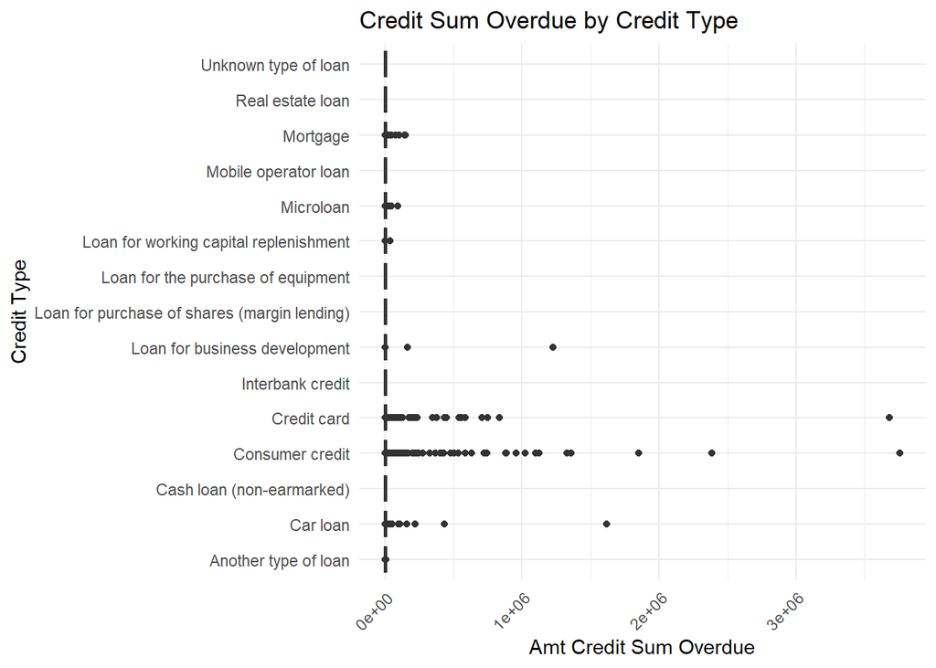

```r
cbu_clean |>
  ggplot(aes(x=CREDIT_TYPE, y=AMT_CREDIT_SUM_OVERDUE)) +
  geom_boxplot() +
  theme_minimal() +
  labs(title = "Credit Sum Overdue by Credit Type",
       x = "Credit Type",
       y = "Amt Credit Sum Overdue") +
  theme(axis.text.x = element_text(angle = 45, hjust = 1))+
  coord_flip()
```

While not an ideal representation of box plot, this does show some categories in credit type have some outliers in sum overdue.

### Previous Applications Data File

#### Summary and search for missing or NA count

```r
#standard summary of Previous Applications file
summary(prev_app)
```

```
##    SK_ID_PREV        SK_ID_CURR     NAME_CONTRACT_TYPE  AMT_ANNUITY
##  Min.   :1000001   Min.   :100001   Length:1670214     Min.   :     0
##  1st Qu.:1461857   1st Qu.:189329   Class :character   1st Qu.:  6322
##  Median :1923111   Median :278715   Mode  :character   Median : 11250
##  Mean   :1923089   Mean   :278357                      Mean   : 15955
##  3rd Qu.:2384280   3rd Qu.:367514                      3rd Qu.: 20658
##  Max.   :2845382   Max.   :456255                      Max.   :418058
##                                                        NA's   :372235
##  AMT_APPLICATION     AMT_CREDIT      AMT_DOWN_PAYMENT    AMT_GOODS_PRICE
##  Min.   :      0   Min.   :      0   Min.   :     -0.9   Min.   :      0
##  1st Qu.:  18720   1st Qu.:  24160   1st Qu.:      0.0   1st Qu.:  50841
##  Median :  71046   Median :  80541   Median :   1638.0   Median : 112320
##  Mean   : 175234   Mean   : 196114   Mean   :   6697.4   Mean   : 227847
##  3rd Qu.: 180360   3rd Qu.: 216418   3rd Qu.:   7740.0   3rd Qu.: 234000
##  Max.   :6905160   Max.   :6905160   Max.   :3060045.0   Max.   :6905160
##                    NA's   :1         NA's   :895844      NA's   :385515
##  WEEKDAY_APPR_PROCESS_START HOUR_APPR_PROCESS_START FLAG_LAST_APPL_PER_CONTRACT
##  Length:1670214             Min.   : 0.00           Length:1670214
##  Class :character           1st Qu.:10.00           Class :character
##  Mode  :character           Median :12.00           Mode  :character
##                             Mean   :12.48
##                             3rd Qu.:15.00
##                             Max.   :23.00
##
##  NFLAG_LAST_APPL_IN_DAY RATE_DOWN_PAYMENT RATE_INTEREST_PRIMARY
##  Min.   :0.0000         Min.   :0.0       Min.   :0.0
##  1st Qu.:1.0000         1st Qu.:0.0       1st Qu.:0.2
##  Median :1.0000         Median :0.1       Median :0.2
##  Mean   :0.9965         Mean   :0.1       Mean   :0.2
##  3rd Qu.:1.0000         3rd Qu.:0.1       3rd Qu.:0.2
##  Max.   :1.0000         Max.   :1.0       Max.   :1.0
##                         NA's   :895844    NA's   :1664263
##  RATE_INTEREST_PRIVILEGED NAME_CASH_LOAN_PURPOSE NAME_CONTRACT_STATUS
##  Min.   :0.4              Length:1670214         Length:1670214
##  1st Qu.:0.7              Class :character       Class :character
##  Median :0.8              Mode  :character       Mode  :character
##  Mean   :0.8
##  3rd Qu.:0.9
##  Max.   :1.0
##  NA's   :1664263
```

[output cut: 33 more lines]

```
##  Min.   : -2801            Min.   : -2889   Min.   : -2874
##  1st Qu.: -1242            1st Qu.: -1314   1st Qu.: -1270
##  Median :  -361            Median :  -537   Median :  -499
##  Mean   : 33768            Mean   : 76582   Mean   : 81992
##  3rd Qu.:   129            3rd Qu.:   -74   3rd Qu.:   -44
##  Max.   :365243            Max.   :365243   Max.   :365243
##  NA's   :673065            NA's   :673065   NA's   :673065
##  NFLAG_INSURED_ON_APPROVAL
##  Min.   :0.0
##  1st Qu.:0.0
##  Median :0.0
##  Mean   :0.3
##  3rd Qu.:1.0
##  Max.   :1.0
##  NA's   :673065
```

Pulling only the numeric or integer types with NA values.

```r
na_prev_app <- colSums(is.na(prev_app))
na_prev_app[na_prev_app > 0]
```

```
##               AMT_ANNUITY                AMT_CREDIT          AMT_DOWN_PAYMENT
##                    372235                         1                    895844
##           AMT_GOODS_PRICE         RATE_DOWN_PAYMENT     RATE_INTEREST_PRIMARY
##                    385515                    895844                   1664263
##  RATE_INTEREST_PRIVILEGED               CNT_PAYMENT        DAYS_FIRST_DRAWING
##                   1664263                    372230                    673065
##            DAYS_FIRST_DUE DAYS_LAST_DUE_1ST_VERSION             DAYS_LAST_DUE
##                    673065                    673065                    673065
##          DAYS_TERMINATION NFLAG_INSURED_ON_APPROVAL
##                    673065                    673065
```

Checking the character data type columns for missing/NA values.

```r
prevapp <- prev_app |>
  select(where(is.character)) |>
  map_df(~ sum(is.na(.) | . == "", na.rm = TRUE)) |> #searching for blank or NA values
  pivot_longer(cols = everything(), names_to = "column", values_to = "blank_count") |>
  filter(blank_count > 0)

prevapp
```

```
## # A tibble: 2 × 2
##   column              blank_count
##   <chr>                     <int>
## 1 NAME_TYPE_SUITE          820405
## 2 PRODUCT_COMBINATION         346
```

Many of the number data type columns have another column with same number of NA values. Based on the description it makes sense that these columns would have same numbers of NA data. With the percentage of values missing in columns, recommend removing all but the Product combination and AMT_CREDIT columns. The Product_combination column should be able to be proportionally modified due to the smaller number of rows being affected at 0.021%. And the AMT_CREDIT column will be updated to match the median value.

#### Previous Application cleaning data

Updating the data for cleaning

```r
clean_prev_app <- prev_app #updating data to be in the clean file
```

```r
#Updating the PRODUCT_COMBINATION
redist_blanks_prev_app <- function(clean_prev_app) {
  column_name <- "PRODUCT_COMBINATION"

  #Remove blank values to calculate the proportion
  non_blank_prod_combo <- clean_prev_app %>%
    filter(!!sym(column_name) !="")

  #Calculate proportions of each non-blank category
  proportion_prevapp <- non_blank_prod_combo %>%
    count(!!sym(column_name)) %>%
    mutate(Prop = n/sum(n)) #proportion of each category

  #Number of blank values to redistribute
  blank_count <- sum(clean_prev_app[[column_name]] == "")

  #Assign blank values
  set.seed(123)

  clean_prev_app[[column_name]][clean_prev_app[[column_name]] == ""] <-sample(
    proportion_prevapp[[column_name]],
    blank_count,
    replace = T,
    prob = proportion_prevapp$Prop
  )

  return(clean_prev_app)
}

#apply this function

clean_prev_app <- redist_blanks_prev_app(clean_prev_app)
```

```r
#Cleaning the AMT_CREDIT with median value for the single missing value
clean_prev_app <- clean_prev_app |>
  mutate(AMT_CREDIT = replace_na(AMT_CREDIT, median(AMT_CREDIT, na.rm = T)))
```

Removing the remaining columns in data file for cleaning.

```r
#Removing columns with NAs in the data
columns_to_remove <- c("AMT_ANNUITY", "AMT_DOWN_PAYMENT", "AMT_GOODS_PRICE", "RATE_DOWN_PAYMENT", "RATE_DOWN_PAYMENT", "RATE_INTEREST_PRIMARY", "RATE_INTEREST_PRIVILEGED", "CNT_PAYMENT", "DAYS_FIRST_DRAWING", "DAYS_FIRST_DUE", "DAYS_LAST_DUE_1ST_VERSION", "DAYS_LAST_DUE", "DAYS_TERMINATION", 'NFLAG_INSURED_ON_APPROVAL", "NAME_TYPE_SUITE')

clean_prev_app <- clean_prev_app[, !(names(clean_prev_app) %in% columns_to_remove)]
```

#### Previous Application Visualizations

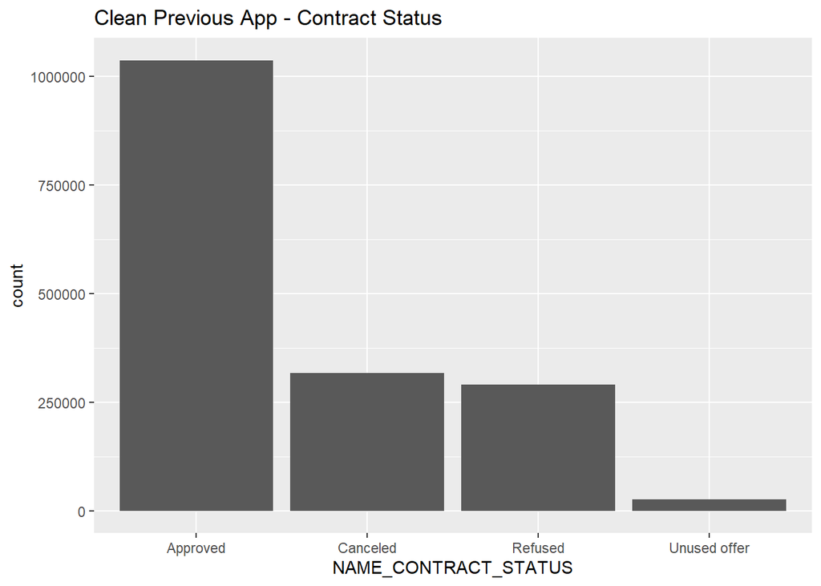

```r
ggplot(clean_prev_app, aes(x = NAME_CONTRACT_STATUS)) +
  geom_bar() +
  labs(title="Clean Previous App - Contract Status")
```

## Joining Data files

Joining the app_train, bureau and previous_applications data files. Beginning the process by reviewing duplicate ID numbers for aggregation.

```r
#Checking the Bureau and Previous Application files for duplicate
cbu_clean %>%
  group_by(SK_ID_CURR) %>%
  summarise(count = n()) %>%
  filter(count > 1) %>%
  arrange(count)
```

```
## # A tibble: 264,291 × 2
##    SK_ID_CURR count
##         <int> <int>
##  1     100004     2
##  2     100010     2
##  3     100019     2
##  4     100022     2
##  5     100043     2
##  6     100054     2
##  7     100062     2
##  8     100064     2
##  9     100072     2
## 10     100083     2
## # ℹ 264,281 more rows
```

```r
clean_prev_app %>%
  group_by(SK_ID_CURR) %>%
  summarise(count = n())%>%
  filter(count >1)%>%
  arrange(count)
```

```
## # A tibble: 278,399 × 2
##    SK_ID_CURR count
##         <int> <int>
##  1     100005     2
##  2     100014     2
##  3     100017     2
##  4     100020     2
##  5     100034     2
##  6     100038     2
##  7     100041     2
##  8     100046     2
##  9     100052     2
## 10     100055     2
## # ℹ 278,389 more rows
```

Many SK_ID_CURR numbers are duplicates in both the Bureau and Previous Application files.

```r
#Aggregating the Bureau clean file
bureau_agg <- cbu_clean %>%
  group_by(SK_ID_CURR) %>%
  summarise(across(where(is.numeric), \(x) sum(x, na.rm = TRUE)),
            across(where(is.character), ~paste(unique(.), collapse = ",")))


#Aggregation for Previous Application clean file
prev_app_agg <- clean_prev_app %>%
  group_by(SK_ID_CURR) %>%
  summarise(across(where(is.numeric), \(x) sum(x, na.rm = TRUE)),
            across(where(is.character), ~paste(unique(.), collapse = ",")))
```

```r
#Joining the files
merged_data <- clean_app_train %>%
  full_join(bureau_agg, by = "SK_ID_CURR") %>%
  full_join(prev_app_agg, by = "SK_ID_CURR")
```

### Exploring merged data

Due to size of the original merged data, sampling the data for some initial analysis

```r
sample_merged <- merged_data %>%
  sample_frac(0.1) #Sampling 10% of the data
```

```r
#potential correlations of data
sample_plot <- sample_merged %>%
  lm(TARGET ~ CREDIT_TYPE, data = .)

summary(sample_plot)
```

```
##
## Call:
## lm(formula = TARGET ~ CREDIT_TYPE, data = .)
##
## Residuals:
##      Min       1Q   Median       3Q      Max
## -0.50000 -0.07934 -0.07934 -0.06726  0.98485
##
## Coefficients:
##                                                                                                                        Estimate
## (Intercept)                                                                                                          -1.209e-12
## CREDIT_TYPEAnother type of loan,Consumer credit                                                                       2.000e-01
## CREDIT_TYPEAnother type of loan,Consumer credit,Car loan                                                              1.165e-12
## CREDIT_TYPEAnother type of loan,Consumer credit,Credit card                                                           2.500e-01
## CREDIT_TYPEAnother type of loan,Consumer credit,Credit card,Car loan                                                  2.656e-12
## CREDIT_TYPEAnother type of loan,Credit card                                                                           1.237e-12
## CREDIT_TYPEAnother type of loan,Credit card,Consumer credit                                                           1.261e-12
## CREDIT_TYPEAnother type of loan,Mortgage,Credit card                                                                  1.794e-12
## CREDIT_TYPECar loan                                                                                                   5.825e-02
## CREDIT_TYPECar loan,Consumer credit                                                                                   6.796e-02
## CREDIT_TYPECar loan,Consumer credit,Credit card                                                                       3.797e-02
## CREDIT_TYPECar loan,Consumer credit,Credit card,Mortgage                                                              1.975e-12
## CREDIT_TYPECar loan,Consumer credit,Mortgage                                                                          1.198e-12
## CREDIT_TYPECar loan,Consumer credit,Mortgage,Credit card                                                              1.157e-12
## CREDIT_TYPECar loan,Credit card                                                                                       5.714e-02
## CREDIT_TYPECar loan,Credit card,Consumer credit                                                                       1.515e-02
## CREDIT_TYPECar loan,Credit card,Consumer credit,Mortgage                                                              1.112e-12
## CREDIT_TYPECar loan,Credit card,Consumer credit,Mortgage,Unknown type of loan                                         1.203e-12
## CREDIT_TYPECar loan,Credit card,Mortgage                                                                              1.169e-12
## CREDIT_TYPECar loan,Credit card,Mortgage,Consumer credit                                                              5.000e-01
## CREDIT_TYPECar loan,Loan for business development                                                                     1.000e+00
## CREDIT_TYPECar loan,Loan for business development,Consumer credit                                                     1.199e-12
## CREDIT_TYPECar loan,Loan for business development,Consumer credit,Credit card                                         1.428e-12
## CREDIT_TYPECar loan,Microloan,Credit card,Consumer credit                                                             1.244e-12
## CREDIT_TYPECar loan,Mortgage                                                                                          1.247e-12
## CREDIT_TYPECar loan,Mortgage,Consumer credit                                                                          1.050e-12
## CREDIT_TYPECar loan,Mortgage,Consumer credit,Credit card                                                              1.112e-12
## CREDIT_TYPECar loan,Mortgage,Credit card,Consumer credit                                                              1.095e-12
## CREDIT_TYPECar loan,Unknown type of loan,Consumer credit                                                              1.263e-12
## CREDIT_TYPEConsumer credit                                                                                            6.726e-02
```

[output cut: 766 more lines]

```
## CREDIT_TYPEMortgage,Consumer credit,Credit card,Car loan
## CREDIT_TYPEMortgage,Consumer credit,Loan for business development
## CREDIT_TYPEMortgage,Consumer credit,Microloan
## CREDIT_TYPEMortgage,Consumer credit,Microloan,Credit card
## CREDIT_TYPEMortgage,Credit card
## CREDIT_TYPEMortgage,Credit card,Consumer credit
## CREDIT_TYPEMortgage,Credit card,Consumer credit,Car loan
## CREDIT_TYPEMortgage,Credit card,Consumer credit,Microloan                                                            **
## ---
## Signif. codes:  0 '***' 0.001 '**' 0.01 '*' 0.05 '.' 0.1 ' ' 1
##
## Residual standard error: 0.2633 on 26299 degrees of freedom
##   (9146 observations deleted due to missingness)
## Multiple R-squared:  0.01128,    Adjusted R-squared:  0.0053
## F-statistic: 1.887 on 159 and 26299 DF,  p-value: 1.205e-10
```

```r
library(broom)

tidy(sample_plot)
```

```
## # A tibble: 160 × 5
##    term                                     estimate std.error statistic p.value
##    <chr>                                       <dbl>     <dbl>     <dbl>   <dbl>
##  1 (Intercept)                             -1.21e-12     0.186 -6.50e-12   1.00
##  2 CREDIT_TYPEAnother type of loan,Consum…  2.00e- 1     0.220  9.08e- 1   0.364
##  3 CREDIT_TYPEAnother type of loan,Consum…  1.17e-12     0.322  3.61e-12   1.00
##  4 CREDIT_TYPEAnother type of loan,Consum…  2.50e- 1     0.228  1.10e+ 0   0.273
##  5 CREDIT_TYPEAnother type of loan,Consum…  2.66e-12     0.322  8.24e-12   1.00
##  6 CREDIT_TYPEAnother type of loan,Credit…  1.24e-12     0.263  4.70e-12   1.00
##  7 CREDIT_TYPEAnother type of loan,Credit…  1.26e-12     0.263  4.79e-12   1.00
##  8 CREDIT_TYPEAnother type of loan,Mortga…  1.79e-12     0.322  5.56e-12   1.00
##  9 CREDIT_TYPECar loan                      5.83e- 2     0.188  3.10e- 1   0.757
## 10 CREDIT_TYPECar loan,Consumer credit      6.80e- 2     0.188  3.62e- 1   0.718
## # ℹ 150 more rows
```